# Code Supplement - Allbee et al. Accepted

Samantha Allbee, Haldre Rogers, and Lauren Sullivan

Last updated: 2022-07-05

This document lays out R code for all analyses and creates figures for “The effect of dispersal, herbivory, and competition on community assembly.” (submitted 2021 to *Ecology*). Code was created by Samantha Allbee and Lauren Sullivan, please contact Samantha (samantha.allbee@gmail.com) or Lauren (llsull@msu.edu) with questions.

# Prolog

```r
# PROLOG   ##############################################################################

# PURPOSE: Examines the role of dispersal in community assembly, and how it interacts with
#             other important community assembly filters.  Fieldwork conducted at Oakridge
#             Research and Education Prairie in 2019.
#
# AUTHORS:  Lauren Sullivan (sullivanll@missouri.edu) and
#             Samantha Allbee (samantha.allbee@gmail.com)
# COLLAB:  Haldre Rodgers
#
# FILES:   "target_plant_movement.csv" - distance moved of 4 target species
#          "target_plant_abundance.csv" - number of stems of 4 target species per plot
#          "community_coverdata.csv" - m2 plot level data collected from the field
#          "spplist_all.csv" - a list of all moved species and their traits
#          "treatment_info_unique.csv" - unique treatment info for plots.
#          "moved_species_ord.csv" - wide format data for ordination of moved species

# PROLOG   ##############################################################################
```

# Libraries and Data

```r
rm(list=ls())



library(lme4)
library(lmerTest)
library(lsmeans)
library(tidyverse)
library(car)
library(plot3D)
library(bbmle)
library(gridExtra)
library(cowplot)
library(vegan)
library(goeveg)
library(plyr)
library(ggResidpanel)
library(PerformanceAnalytics)



disp <- read.csv("target_plant_movement.csv")
dat <- read_csv("community_coverdata.csv")
spp <- read_csv("spplist_all.csv")
trt <- read_csv("treatment_info_unique.csv")
t_abund <- read_csv("target_plant_abundance.csv")
movedord <- read.csv("moved_species_ord.csv")
coverord <- read.csv("all_species_ord.csv")


dat <- merge(dat, spp, by=c("sixletter_code"))
```

# Target Plant Movement Analyses

## Distance - Dispersal Kernels

Here we examine the distance that the 4 target species moved and established away from the central high diversity cores both inside and outside the herbivore plots.

```r
disp$species <- factor(disp$species, levels = c("bapalb", "eryyuc", "pendig", "asteri"),
                      labels = c("B. alba", "E. yuccifolium", "P. digitalis", "S. ericoides"))

disp$plot <- factor(disp$plot)

######
#
# Figure S4 - density plot of movement distance of all species by herbivore treatment
#
######

pdf(file="Fig_S4_herbivorekernels.pdf",width=7, height=7)

ggplot(disp, aes(x=distance_from_edge, fill=trt, color=trt))+
  geom_density(alpha = 0.5)+
  theme_bw()+
  theme(aspect.ratio=1)+
  labs(x="Distance from Core Edge", y="Density")+
  theme(text = element_text(size = 22))+
  scale_fill_manual(values=c("gray25", "gray75"))+
  scale_color_manual(values=c("gray25", "gray75"))

dev.off()
```

```r
disp$trt <- factor(disp$trt, levels = c("herb", "no_herb"),
                      labels = c("herbivores", "no herbivores"))


#quantiles to explore how herbivores alter movement overall

quantile(subset(disp, trt == "herbivores")$distance_from_edge, c(0.01, 0.05, 0.25, 0.5, 0.75, 0.95, 0.99))
```

```
##        1%        5%       25%       50%       75%       95%       99%
##  0.047800  0.101400  0.508800  1.124757  8.120853 11.994000 12.267600
```

```r
quantile(subset(disp, trt == "no herbivores")$distance_from_edge, c(0.01, 0.05, 0.25, 0.5, 0.75, 0.95, 0.99))
```

```
##         1%         5%        25%        50%        75%        95%        99%
##  0.0328745  0.1180500  0.5263750  1.1527000  2.3750500  9.0678700 10.6803410
```

```r
######
#
# GLMER analysis of distance moved ~ treatment * species
#
######

test1.gamma <- glm(distance_from_edge ~ trt + species, family = Gamma, data = disp)
Anova(test1.gamma,  type = 3)
```

```
## Analysis of Deviance Table (Type III tests)
##
## Response: distance_from_edge
##         LR Chisq Df Pr(>Chisq)
## trt        7.203  1   0.007279 **
## species  113.311  3  < 2.2e-16 ***
## ---
## Signif. codes:  0 '***' 0.001 '**' 0.01 '*' 0.05 '.' 0.1 ' ' 1
```

```r
#resid_panel(test1.gamma)


######
#
# Figure 2 - dispersal kernels of 4 target species by species and treatment
#
######

color_cb <- c("#D55E00", "#F0E442", "#009E73", "#0072B2")

pdf(file="Fig_2_herbivore_spp_kernels.pdf",width=10, height=7)

ggplot(disp, aes(x=distance_from_edge, fill=species, color=species))+
  geom_density(alpha = 0.5)+
  facet_wrap(facets = "trt")+
  theme_bw()+
  theme(aspect.ratio=1)+
  labs(x="Distance from Core Edge",
       y="Density",
       fill = "Species", color = "Species")+
  theme(text = element_text(size = 22))+
  scale_fill_manual(values=color_cb)+
  scale_color_manual(values=color_cb)+
  theme(legend.text = element_text(face = "italic"))

dev.off()
```

```r
#quantiles for Herbivore trt * species
quantile(subset(disp, trt == "herbivores")$distance_from_edge, c(0.01, 0.05, 0.25, 0.5, 0.75, 0.95, 0.99))
```

```
##        1%        5%       25%       50%       75%       95%       99%
##  0.047800  0.101400  0.508800  1.124757  8.120853 11.994000 12.267600
```

```r
quantile(subset(disp, trt == "herbivores" & species == "P. digitalis")$distance_from_edge, c(0.01, 0.25, 0.5, 0.75, 0.99))
```

```
##       1%      25%      50%      75%      99%
## 0.047220 0.223000 0.973250 1.107223 1.557580
```

```r
quantile(subset(disp, trt == "no herbivores" & species == "P. digitalis")$distance_from_edge, c(0.01, 0.25, 0.5, 0.75, 0.99))
```

```
##        1%       25%       50%       75%       99%
## 0.0292625 0.5263750 0.6873500 1.3904750 2.7473750
```

```r
quantile(subset(disp, trt == "herbivores" & species == "E. yuccifolium")$distance_from_edge, c(0.01, 0.25, 0.5, 0.75, 0.99))
```

```
##        1%       25%       50%       75%       99%
## 0.7827242 1.7361040 2.7292080 3.7223120 4.6756918
```

```r
quantile(subset(disp, trt == "no herbivores" & species == "E. yuccifolium")$distance_from_edge, c(0.01, 0.25, 0.5, 0.75, 0.99))
```

```
##       1%      25%      50%      75%      99%
## 0.159036 0.495900 0.579000 1.275000 3.038520
```

```r
quantile(subset(disp, trt == "herbivores" & species == "S. ericoides")$distance_from_edge, c(0.01, 0.25, 0.5, 0.75, 0.99))
```

```
##        1%       25%       50%       75%       99%
##  6.315585  9.064235 11.178680 11.971500 12.362500
```

```r
quantile(subset(disp, trt == "no herbivores" & species == "S. ericoides")$distance_from_edge, c(0.01, 0.25, 0.5, 0.75, 0.99))
```

```
##       1%      25%      50%      75%      99%
##  0.10995  1.55700  4.28965  6.05740 10.74123
```

```r
quantile(subset(disp, trt == "herbivores" & species == "B. alba")$distance_from_edge, c(0.01, 0.25, 0.5, 0.75, 0.99))
```

```
##       1%      25%      50%      75%      99%
## 0.084544 0.508800 0.790000 2.630000 4.275480
```

```r
quantile(subset(disp, trt == "no herbivores" & species == "B. alba")$distance_from_edge, c(0.01, 0.25, 0.5, 0.75, 0.99))
```

```
##       1%      25%      50%      75%      99%
## 0.162934 0.305350 0.453700 1.096350 1.713294
```

## Stem Abundance

Here we examine how the total number of stems in all plots of our 4 target species differs with herbivore exclusion.

```r
######
#
# Appendix S3: GLMER analysis of number of established stems ~ treatment * species
#
######


test2.nb <- glmer.nb(total ~ treatment + species  + (1|plot),  data = t_abund, verbose = TRUE)
```

```
## th := est_theta(glmer(..)) = 1.963966 --> dev.= -2*logLik(.) = 229.2103
##  1: th=   0.9673082543, dev=  232.00284065, beta[1]=    1.22654578
##  2: th=    3.987521279, dev=  235.13701283, beta[1]=    1.19207607
##  3: th=   0.4030775664, dev=  247.92436238, beta[1]=    1.21579880
##  4: th=    1.734425425, dev=  229.01033542, beta[1]=    1.23924238
##  5: th=    1.732285557, dev=  229.00983849, beta[1]=    1.23919883
##  6: th=    1.696966748, dev=  229.00586380, beta[1]=    1.23865927
##  7: th=    1.697388797, dev=  229.00586321, beta[1]=    1.23866938
##  8: th=    1.697360494, dev=  229.00586322, beta[1]=    1.23866563
##  9: th=    1.697417101, dev=  229.00586322, beta[1]=    1.23866553
## 10: th=    1.697388797, dev=  229.00586321, beta[1]=    1.23866553
```

```r
Anova(test2.nb, type = 3)
```

```
## Analysis of Deviance Table (Type III Wald chisquare tests)
##
## Response: total
##               Chisq Df Pr(>Chisq)
## (Intercept) 12.0620  1  0.0005146 ***
## treatment    5.5342  1  0.0186487 *
## species     38.9326  3  1.794e-08 ***
## ---
## Signif. codes:  0 '***' 0.001 '**' 0.01 '*' 0.05 '.' 0.1 ' ' 1
```

```r
#resid_panel(test2.nb)


######
#
# Appendix S3: Figure - abundance of 4 target species per treatment
#
######



abund_dat <- t_abund %>%
  mutate(treat_nice = case_when(
    str_detect(treatment, "herbivores") ~ "Herbivores",
    str_detect(treatment, "no_herb") ~ "No Herbivores")) %>%
  mutate(spec_name_nice = case_when(
    str_detect(species, "pendig") ~ "Penstemon digitalis",
    str_detect(species, "eryyuc") ~ "Eryngium yuccifolium" ,
    str_detect(species, "bapalb") ~ "Baptisia alba" ,
    str_detect(species, "asteri") ~ "Symphyotrichum ericoides"))


pdf(file="FigS3_stemabundance.pdf", width=10, height=7)

ggplot(abund_dat, aes(x = spec_name_nice, y = total)) +
  geom_boxplot(aes(fill = treat_nice)) +
  labs(x = "Species", y = "Number of Individuals" , fill = NULL) +
  theme(axis.text.x = element_text(face = "italic"))+
  theme_bw()+
  scale_fill_manual(values=c("gray25", "gray75"))

dev.off()
```

# Community Composition Analyses

## Alpha Diversity

Here we examine the alpha diversity of all moved core species across all treatments (distance, competition (covered/uncovered), herbivores). We also examined the alpha diveristy of the entire community (all moved species, plus everything else in the core.)

RESULTS: MOVED SPECIES - More core species moved to near plots as opposed to far, covered plots had more core species than uncovered plots, and herbivores did not have an effect on the diversity of core species within the plots. ALL SPECIES - When looking at all species, not just the moved species, we found a significant effect of distance, and a marinal effect of competition, and no effect of herbivore treatment.

```r
#get only core species
high_div_move_alpha <- ddply(subset(dat, core_only=="yes"), .(plot, distance, transect, cover_status),
                             summarize,
                             alpha = length(unique(sixletter_code)),
                             sum_cover_core = sum(percent_cover))



#make these factors
high_div_move_alpha <- left_join(high_div_move_alpha, trt)
high_div_move_alpha$transect <- as.factor(high_div_move_alpha$transect)
high_div_move_alpha$plot <- as.factor(high_div_move_alpha$plot)



######
#
# LMER analysis of alpha diversity ~ dispersal * herbivory * competition MOVED SPECIES
#
######

test3_lme <- lmer(alpha ~ treatment + cover_status + distance + (1|plot/trans_unique),
                  data=high_div_move_alpha, REML=TRUE)
Anova(test3_lme,  type = 3)
```

```
## Analysis of Deviance Table (Type III Wald chisquare tests)
##
## Response: alpha
##                 Chisq Df Pr(>Chisq)
## (Intercept)   12.8140  1   0.000344 ***
## treatment      1.9772  1   0.159688
## cover_status  32.8346  1  1.003e-08 ***
## distance     137.1139  1  < 2.2e-16 ***
## ---
## Signif. codes:  0 '***' 0.001 '**' 0.01 '*' 0.05 '.' 0.1 ' ' 1
```

[figure not shown]

[output not shown]

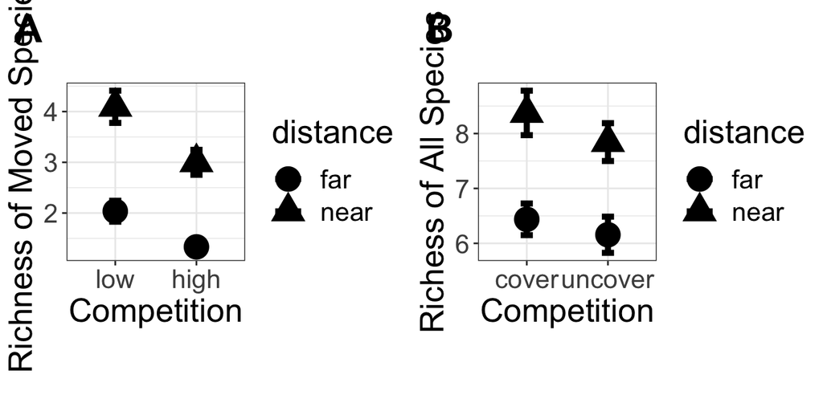

```r
######
#
# Figure 3a - alpha diversity with competition and herbivory treatments of MOVED species
#
######

# stats summary


stats_alpha <- high_div_move_alpha %>%
              group_by(., distance, cover_status) %>%
              dplyr::summarize(., mean_alpha = mean(alpha),
                     se_alpha = sd(alpha)/sqrt(length(alpha)-1),
                     mean_cover = mean(sum_cover_core),
                     se_cover = sd(sum_cover_core)/sqrt(length(sum_cover_core)-1),
                     sd_cover = sd(sum_cover_core))


stats_alpha$cover_status <- factor(stats_alpha$cover_status, levels = c("cover", "uncover"),labels = c("low", "high"))





Fig3a <- ggplot(stats_alpha, aes(x=cover_status, y=mean_alpha, shape = distance))+
                geom_errorbar(aes(ymax = mean_alpha + se_alpha,
                                  ymin = mean_alpha - se_alpha,
                                  color = distance), width = 0.15, lwd = 1.75)+
                geom_point(cex = 7)+
                theme_bw()+
                theme(aspect.ratio=1)+
                scale_color_manual(values = c("black", "black"))+
                labs(x="Competition",
                     y="Richness of Moved Species")+
                theme(text = element_text(size = 20))
```

## Community Composition

Here we examine how all treatments (distance, competition (covered/uncovered), herbivores) altered the community composition of **just** moved core species as these show evidence of assembly into local communities from the regional species pool.

```r
#ORDINATION WITH SPECIES THAT MOVED FROM THE CORE

dat_moved <- movedord[,6:23]

# standardize for presence/absence
datmoved_d <- decostand(dat_moved, "pa")

#subset environmental data
dat_env <- movedord[,1:5]
```

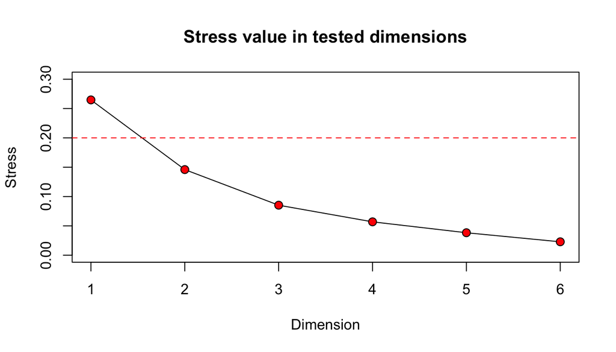

```r
#dimension check - use k = 3
dimcheckMDS(datmoved_d, distance = "jaccard", k = 6, trymax = 10,
            autotransform = FALSE)
```

```r
#create NMDS
NMDS_core_jaccard <- metaMDS(datmoved_d, distance = "jaccard", k = 3, try = 50,
                             trymax = 70, autotransform = F, expand = F,
                             trace = FALSE)

#make  distance matrix
dat.jaccard.moved <- vegdist(datmoved_d, "jaccard")


######
#
# PERMANOVA for how herbivores, competition and distance influences jaccard dissimilarity in composition,
#               blocked by plot for moved species
#
######

adonis2(dat.jaccard.moved ~ herbivores + cover_status + distance , data = dat_env,
       strata = dat_env$plot)
```

```
## Permutation test for adonis under reduced model
## Terms added sequentially (first to last)
## Blocks:  strata
## Permutation: free
## Number of permutations: 999
##
## adonis2(formula = dat.jaccard.moved ~ herbivores + cover_status + distance, data = dat_env, strata = dat_env$plot)
##               Df SumOfSqs      R2       F Pr(>F)
## herbivores     1   1.9786 0.07085  9.6449  0.001 ***
## cover_status   1   0.7976 0.02856  3.8881  0.002 **
## distance       1   2.1750 0.07788 10.6023  0.001 ***
## Residual     112  22.9758 0.82271
## Total        115  27.9269 1.00000
## ---
## Signif. codes:  0 '***' 0.001 '**' 0.01 '*' 0.05 '.' 0.1 ' ' 1
```

```r
######
#
# Figure S3 - composition differences with treatment (herbivory, competition, dispersal)
#
######


scores_moved <- scores(NMDS_core_jaccard)
scores_moved2 <- cbind(scores_moved$sites, dat_env)

col <- c("#80CDC1","#BF812D")

#Covered/Uncovered Plots - 2D
cover <- ggplot(scores_moved2, aes(x=NMDS1, y=NMDS2, color=cover_status))+
            geom_point(size = 4)+
            scale_colour_manual(values=col)+
            theme_bw()

#Distance plot - 2D
dist <- ggplot(scores_moved2, aes(x=NMDS1, y=NMDS2, color=distance))+
            geom_point(size=4)+
            scale_colour_manual(values=col)+
            theme_bw()

#herbivores plot - 2D
herb <- ggplot(scores_moved2, aes(x=NMDS2, y=NMDS1, color=herbivores))+
            geom_point(size=4)+
            scale_colour_manual(values=col)+
            theme_bw()


pdf(file="Fig_S3_moved_composition.pdf", width=10, height=7)

plot_grid(cover, dist, herb,
          width = 4, height = 6,
          nrow=3)

dev.off()
```

# Species Trade-off Analysis

Here we examine which plots species are able to establish in: 1) near vs far plots, 2) competitive vs uncompetitive plots, and 3) herbivores vs no herbivores to determine how species are able to trade off in their ability to withstand different assembly filters as they establish.

## Calculate Occurrence Ratios

Here we calculate occurrence ratios in the different treatments.

```r
## species level movement
spp_level_move <- subset(dat, core_only=="yes")


#######
#
# OCCURRENCE - Competition
#
#######



#merge in treatment data
spp_level_move <- merge(spp_level_move, trt, by=c("plot", "transect"))

#make these factors
spp_level_move$transect <- as.factor(spp_level_move$transect)
spp_level_move$plot <- as.factor(spp_level_move$plot)



## who is moving to uncovered plots over covered plots.

#summarize occurrence of the moved species in covered vs uncovered plots
comp <- spp_level_move %>%
    group_by(sixletter_code, cover_status) %>%
    dplyr::summarize(occurrence = sum(length(sixletter_code)))

comp <- comp[,1:3]
colnames(comp)[3] <- "comp_occurrence"

comp$comp_prop_occurrence <- (comp$comp_occurrence)/64


# Replaced all "NA"'s with 0.01, which is just slightly less than plants showing up in 1/64 plots
#   For the comp. analysis: this NA issue only occurs for plants that are not showing up frequently
#     at all (like typically one or two times total), so this keeps the numbers reasonable.
comp2 <- spread(comp[,-3], key = cover_status, value = comp_prop_occurrence) %>%
          replace(., is.na(.), 0.01)

# Here, divide uncover by cover, so a number >1 means competition promotes establishment
#       (plants prefer more competition)
comp2$comp_ratio <- comp2$uncover / comp2$cover




#######
#
# OCCURRENCE - Prop Dispersal
#
#######


#summarize occurrence of the moved species in near and far plots
disp <- spp_level_move %>%
    group_by(sixletter_code, distance) %>%
    dplyr::summarize(occurrence = sum(length(sixletter_code)))

disp <- disp[,1:3]
colnames(disp)[3] <- "disp_occurrence"

disp$disp_prop_occurrence <- (disp$disp_occurrence)/64


disp2 <- spread(disp[,-3], key = distance, value = disp_prop_occurrence) %>%
          replace(., is.na(.), 0.01)

# Here, divide far by near.  Which means a number > 1 means they disperse farther.
#
disp2$disp_ratio <- disp2$far / disp2$near




#######
#
# OCCURRENCE - Prop Herbivore
#
#######


#summarize occurrence of the moved species in herbivore and no herbivore plots
herb <- spp_level_move %>%
    group_by(sixletter_code, treatment) %>%
    dplyr::summarize(occurrence = sum(length(sixletter_code)))

herb <- herb[,1:3]
colnames(herb)[3] <- "herb_occurrence"

herb$herb_prop_occurrence <- (herb$herb_occurrence)/64

herb2 <- spread(herb[,-3], key = treatment, value = herb_prop_occurrence) %>%
          replace(., is.na(.), 0.01)


# Here, divide herbivores over no_herbivores, so a number >1 means herbivores promote establishment.
#
herb2$herb_ratio <- herb2$herbivores / herb2$no_herbivores



#######
#
# OCCURRENCE - Combining it all
#
#######


occurrence <- full_join(herb2[,-(2:3)], disp2[,-(2:3)], by = "sixletter_code" ) %>%
                full_join(., comp2[, -(2:3)], by = "sixletter_code")

tmp_df<-data.frame(occurrence)
rownames(tmp_df)<-occurrence$sixletter_code


### correlation plot - Fig S5

tiff(file="Fig_S5_correlation.tiff")

chart.Correlation(
  occurrence[,-1],
  histogram = TRUE,
  method = c("pearson")
)

dev.off
```

[output not shown]

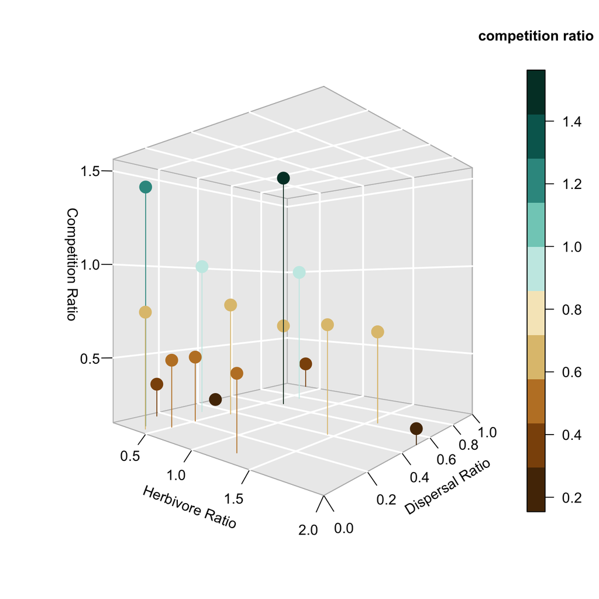

```r
col <- c('#543005','#8c510a','#bf812d','#dfc27d','#f6e8c3','#c7eae5','#80cdc1','#35978f','#01665e','#003c30')


######
#
# Figure 5 - species trade-offs between dispersal, herbivory tolerance and competition ability.  All species labels were added in Adobe after creating the base figure in R.
#
######

scatter3D(occurrence$herb_ratio, occurrence$disp_ratio, occurrence$comp_ratio,
          labels = rownames(occurrence),  clab = c("competition ratio"),
          col = col,
          phi = 0, bty ="g", pch = 16, cex = 2,
          type = "h",
          ticktype = "detailed",
          ylim = c(0,1),
          xlab = "Herbivore Ratio", ylab ="Dispersal Ratio", zlab = "Competition Ratio")
```